# spsurveyME2015

Bryan Milstead

Monday, July 27, 2015

## Introduction

- Linda Bacon has asked for a selection of 30 ME lakes for Cyanobacteria monitoring during the summer of 2015 with an unstratified equal probability design.
- The sampling frame is a shapefile (Lakesover150A.shp) from Linda with a set of 45 lakes > 150 acres in Androscoggin, Knox, Lincoln and Sagadahoc counties (Maine)
- The R package spsurvey will be used to select the lakes following the 1st example in http://cran.r-project.org/web/packages/spsurvey/vignettes/Finite_Design.pdf by Thomas Kincaid.
- This same approach was used last year. See: https://github.com/willbmisled/2014/spsurveyME2014.md
- The final document for the 2015 draw is available here: https://github.com/willbmisled/2015/spsurveyME2015.md
- The complete document with code chunks is here: https://github.com/willbmisled/2015/spsurveyME2015.rmd

## Workflow

- load r packages: spsurvey, sp, maptools, rgdal
- read the sample frame (Lakesover150A.shp)
- reproject data from NAD_1983_UTM_Zone_19N to Albers
- Convert from spatialPolygonsDataFrame to a spatialPointsDataFrame based on centroids
- draw 30 lakes from sample frame with the spsurvey GRTS unstratified, equal probability design

# Results

Below is a list of the selected sites. The siteIDs are assigned by SPsurvey. The idea is that you select the sites in order of the siteIDs. If a site cannot be visited for any reason choose the next site from the list. There is also a rough figure showing all of the lakes as polygons and the selected lakes as the blue centroids.

```
##     siteID            LAKENAME MIDAS_NUM
## 1  Site-01     Washington Pond      4894
## 2  Site-02           Long Pond      3816
## 3  Site-03 Upper Pleasant Pond      5254
## 4  Site-04        Medomak Pond      5692
## 5  Site-05       Sennebec Pond      5682
## 6  Site-06           The Heath      3444
## 7  Site-07        Carvers Pond      5520
## 8  Site-08   Sidensparker Pond      5722
## 9  Site-09         Turner Pond      4906
## 10 Site-10       Pleasant Pond      3822
## 11 Site-11          Clary Lake      5382
## 12 Site-12        McCurdy Pond      5712
## 13 Site-13         Grassy Pond      4812
## 14 Site-14         Taylor Pond      3750
```

[output cut: 16 more lines]

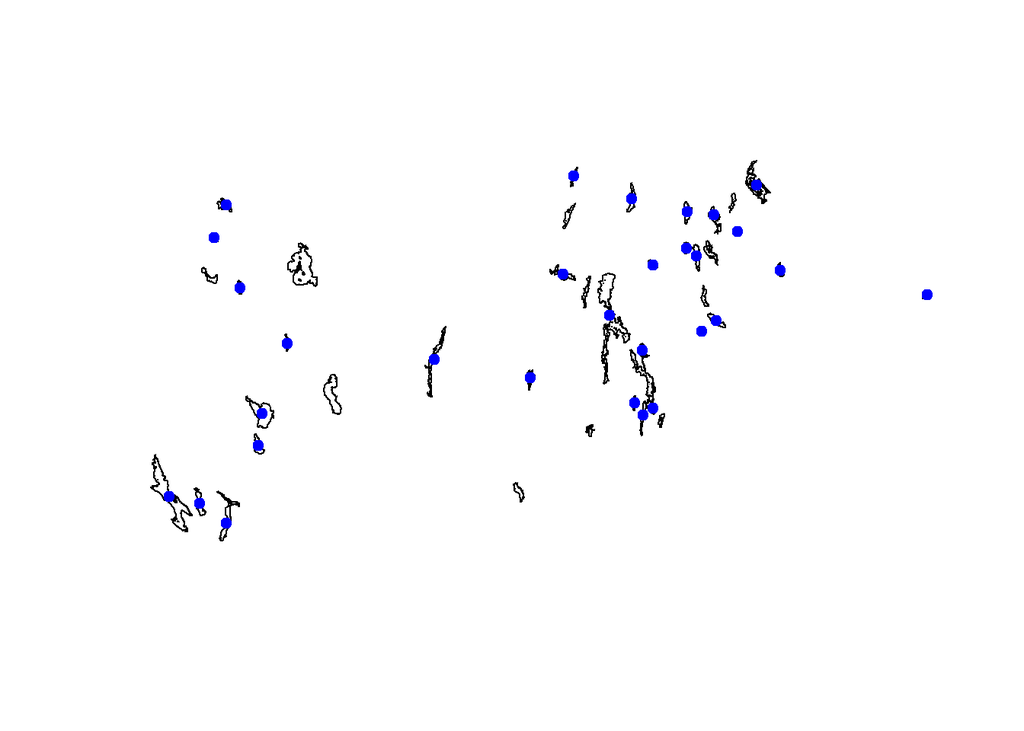